# 单变量绘图选择

查看数据集结构和特征

```
## [1] 113937     81
```

这个数据集拥有81个特征，这里不准备全部讨论，只是重点查看某些感兴趣的特征——共选取14个感兴趣的特征。

```
## 'data.frame':    113937 obs. of  14 variables:
##  $ ProsperRating..Alpha.      : Factor w/ 8 levels "","A","AA","B",..: 1 2 1 2 6 4 7 5 3 3 ...
##  $ ProsperRating..numeric.    : int  NA 6 NA 6 3 5 2 4 7 7 ...
##  $ LP_GrossPrincipalLoss      : num  0 0 0 0 0 0 0 0 0 0 ...
##  $ DebtToIncomeRatio          : num  0.17 0.18 0.06 0.15 0.26 0.36 0.27 0.24 0.25 0.25 ...
##  $ MonthlyLoanPayment         : num  330 319 123 321 564 ...
##  $ LoanOriginalAmount         : int  9425 10000 3001 10000 15000 15000 3000 10000 10000 10000 ...
##  $ ListingCategory..numeric.  : int  0 2 0 16 2 1 1 2 7 7 ...
##  $ LoanCurrentDaysDelinquent  : int  0 0 0 0 0 0 0 0 0 0 ...
##  $ LoanStatus                 : Factor w/ 12 levels "Cancelled","Chargedoff",..: 3 4 3 4 4 4 4 4 4 4 ...
##  $ EstimatedReturn            : num  NA 0.0547 NA 0.06 0.0907 ...
##  $ ProsperScore               : num  NA 7 NA 9 4 10 2 4 9 11 ...
##  $ CurrentDelinquencies       : int  2 0 1 4 0 0 0 0 0 0 ...
##  $ AmountDelinquent           : num  472 0 NA 10056 0 ...
##  $ ProsperPrincipalOutstanding: num  NA NA NA NA 9948 ...
```

首先查看prosper的自定义评级。运行str()后，发现A和AA顺序错误，因此需要修改。且信用未登记的条目并没有对应的文字显示，只是一个空值，因此还要在坐标图中将空值改为“NA”来注明。同时还发现ProsperRating..numeric.包含空值，但是特征说明中规定空值NA应为0，因此也需要修改。

```
##
##          HR     E     D     C     B     A    AA
## 29084  6935  9795 14274 18345 15581 14551  5372
```

```
##
##     0     1     2     3     4     5     6     7
## 29084  6935  9795 14274 18345 15581 14551  5372
```

修改特征后的prosper的自定义评级分布如下图。

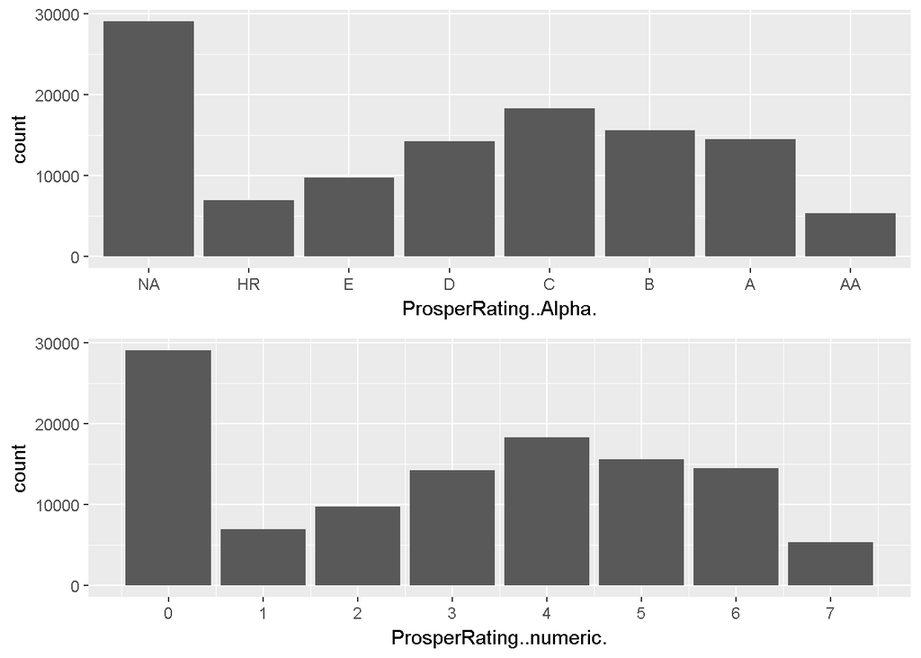

忽略未登记信用评级的条目，可以看到信用评级趋于正态分布，C评级的人数最多，AA最高评级的人数最少。

之后查看风险系数(应按照特征说明将1-11更改0-10，并改为因子变量，为了后面计算相关系数方便，因此保留num特征，并新建一个因子变量)、贷款用途(和风险系数处理的方法相同，保留原变量，转换因子变量并新建)、贷款初始金额、预估回报分布、借贷收入比、按月还贷额的分布。

```
##
##     0     1     2     3     4     5     6     7     8     9    10
##   992  5766  7642 12595  9813 12278 10597 12053  6911  4750  1456
```

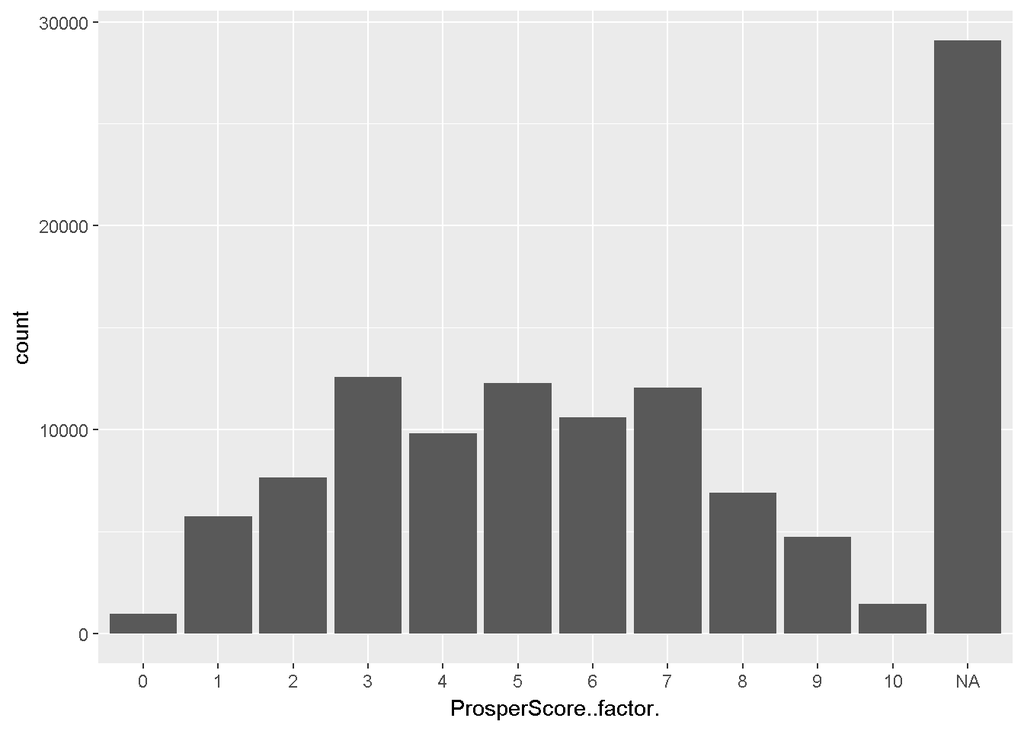

忽略风险系数未登记的条目的话，可以看出此特征也呈现正态分布的趋势，3-7的数量稍多，但也有小波动，因此并不是严格的正态分布。最少数量的风险系数是0。

```
##
##     0     1     2     3     4     5     6     7     8     9    10    11
## 16965 58308  7433  7189  2395   756  2572 10494   199    85    91   217
##    12    13    14    15    16    17    18    19    20
##    59  1996   876  1522   304    52   885   768   771
```

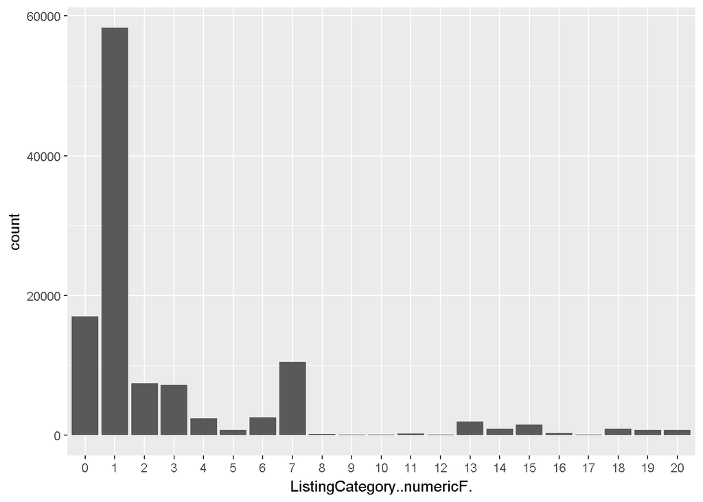

贷款用途分布中，1-DebtConsolidation的数量是最多的。忽略0-NotAvailabel，7-Other的数量排在第二位，2-HomeImprovement和3-Business二者数量也稍多一些，剩下的则普遍很少。

```
##    Min. 1st Qu.  Median    Mean 3rd Qu.    Max.
##    1000    4000    6500    8337   12000   35000
```

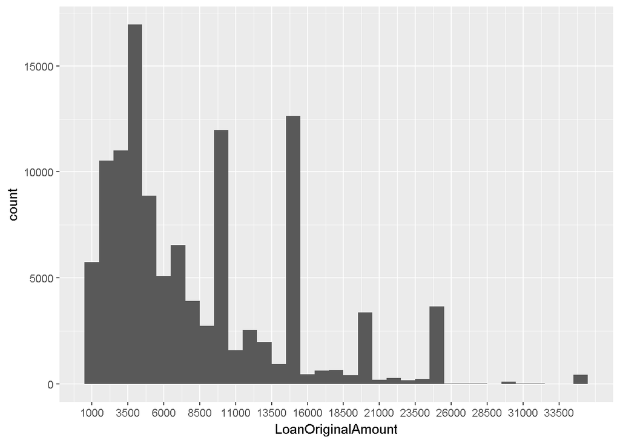

贷款初始金额分布可以看到三个明显的划分区间：最小值1000-10000，10000-25000，25000以上，75%的人借款不会超过12000。4000、10000、15000可以看到是明显的区间内峰值，可能和平时的“取整”习惯有关。最大借款额为35000。

```
##    Min. 1st Qu.  Median    Mean 3rd Qu.    Max.    NA's
##  -0.183   0.074   0.092   0.096   0.117   0.284   29084
```

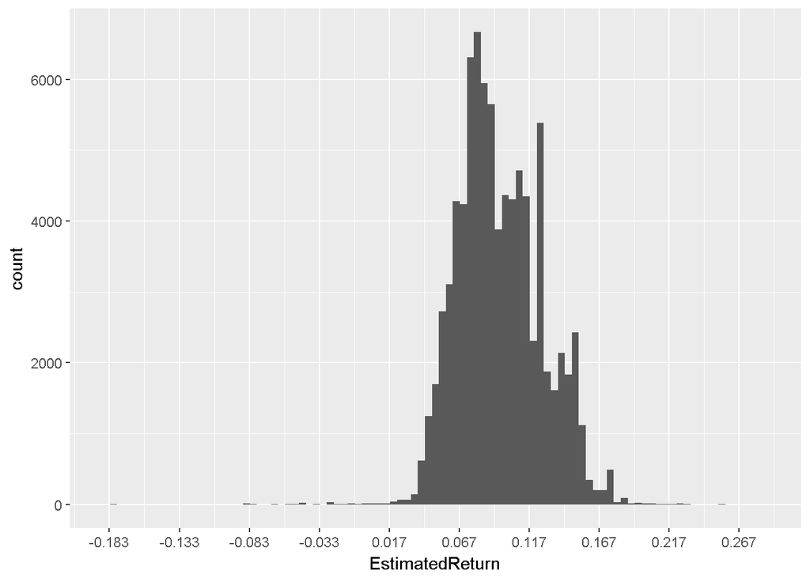

预估回报也可以粗略看成正态分布，且median和mean的值相差不多。可以看到大部分预估回报都在0.017和0.192之间，75%的预估回报不会超过0.117。但同时也可以看到，有的预估回报是负数，即最小值并不是0。最大回报率也不超过0.284。

```
##    Min. 1st Qu.  Median    Mean 3rd Qu.    Max.    NA's
##   0.000   0.140   0.220   0.276   0.320  10.010    8554
```

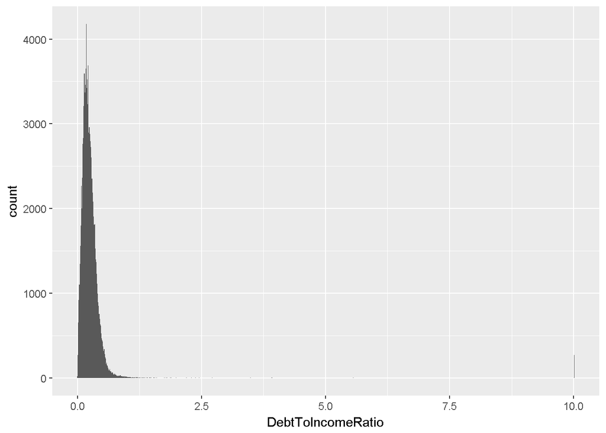

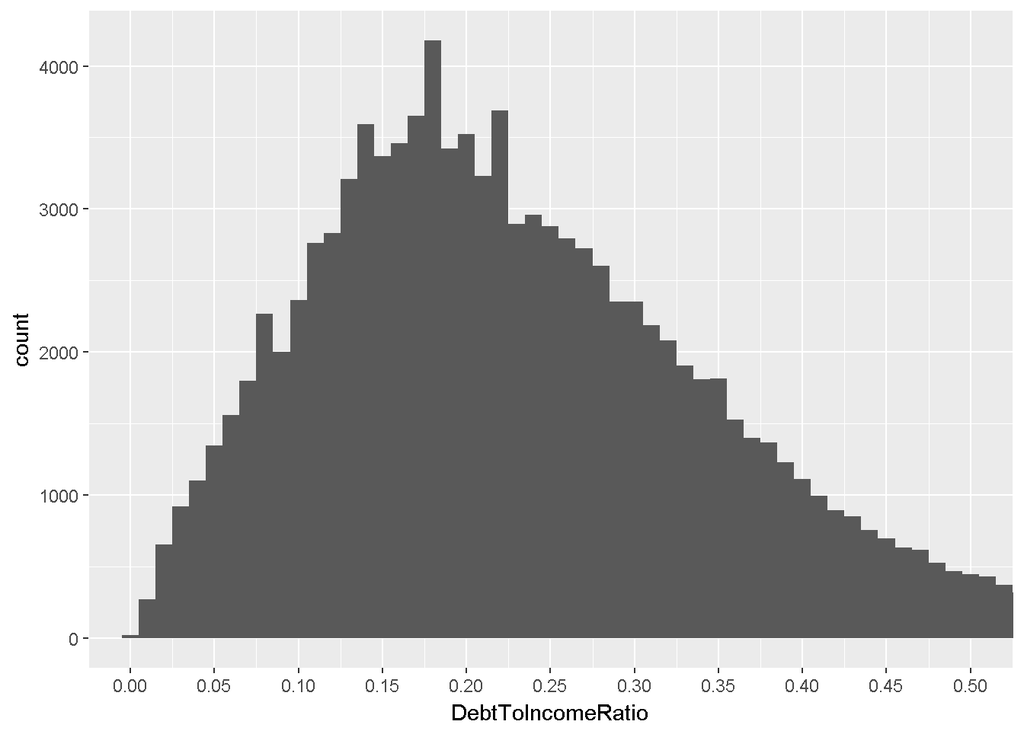

一部分的借贷收入比超过了1000%(被标记为10.1的条目)。忽略top5%放大来看分布情况。借贷收入比在0.15到0.2的人居多，75%的人的借贷收入比在0.32以内，是一个可以负担得起的比值。

```
##    Min. 1st Qu.  Median    Mean 3rd Qu.    Max.
##     0.0   131.6   217.7   272.5   371.6  2251.5
```

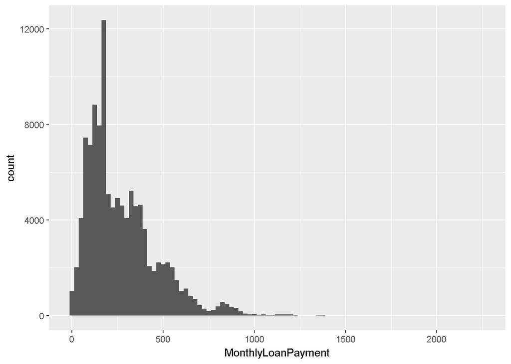

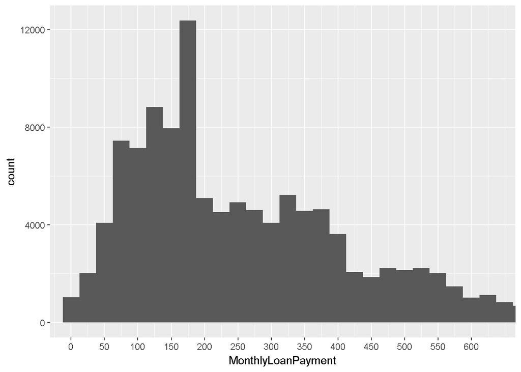

75%的人按月还贷额在371.6以内，最大额为2251.5，平均为272.5。但是高额按月还贷的分布很广而且密度稀，因此忽略top5%再查看分布。每月还贷175是频率最大值，图中三个最明显的区间就是0-175，175-400，400以上，金额越高，频率越低。

查看贷款状态分布，原始图显示有序因子的排序有错误，需要修改。修改后如图。

```
##
##               Cancelled              Chargedoff               Completed
##                       5                   11992                   38074
##                 Current               Defaulted Final PaymentInProgress
##                   56576                    5018                       0
##    Past Due (1-15 days)   Past Due (16-30 days)   Past Due (31-60 days)
##                     806                     265                     363
##   Past Due (61-90 days)  Past Due (91-120 days)    Past Due (>120 days)
##                     313                     304                      16
```

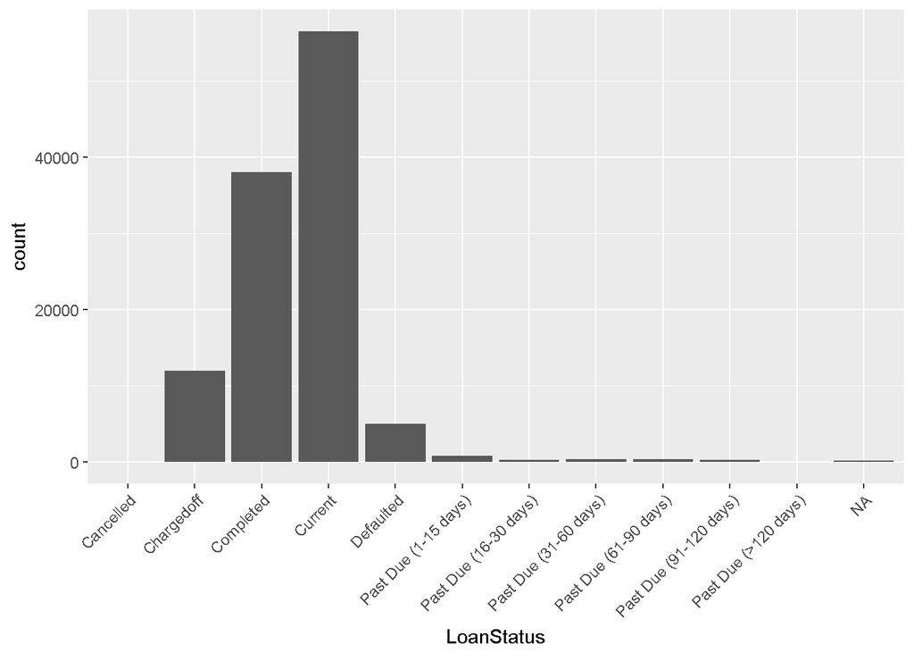

可以看到，大部分的贷款还是处于正常交易中的。

查看拖欠天数分布和贷款总耗损金额分布。在查看分布时发现大部分拖欠天数和耗损金额都为0，因此重点查看大于0的拖欠天数和耗损金额分布。由于天数分布较广，因此图中设置binwidth为30，令天数按照月份为单位来划分，x轴则按年数显示天数，同时x轴改为“年数”。

```
##    Min. 1st Qu.  Median    Mean 3rd Qu.    Max.
##     0.0     0.0     0.0   152.8     0.0  2704.0
```

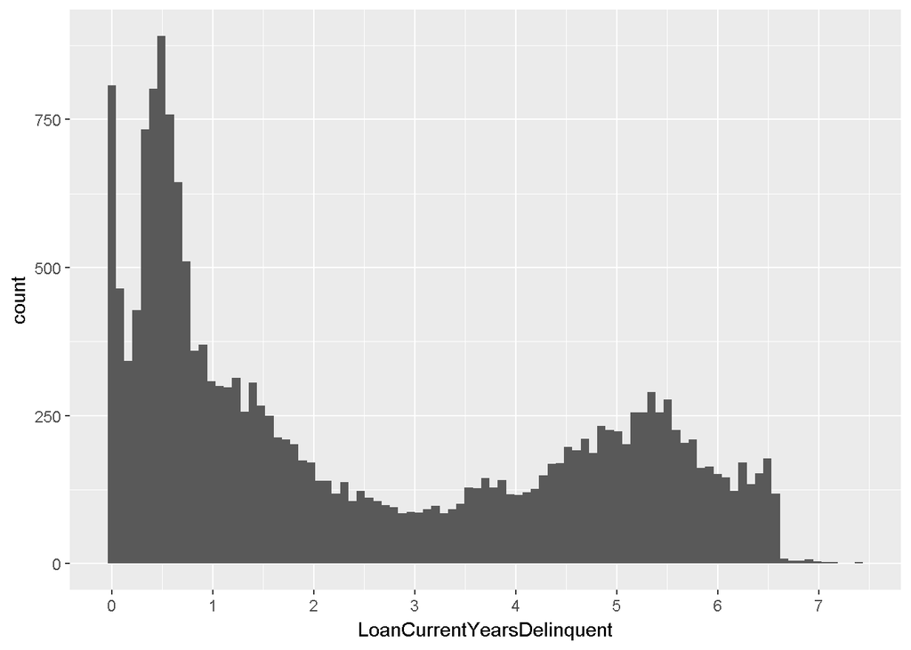

图中可以看到两个拖欠年数的波动，转折点在3年。但通过summary可以看出来75%的借款是没有拖欠的，但最大的年数也是7年多了。大部分的拖欠年数也都在两年内，在长久拖欠区间内，高峰值是五年半。

查看贷款总耗损的分布。

```
##    Min. 1st Qu.  Median    Mean 3rd Qu.    Max.
##   -94.2     0.0     0.0   700.4     0.0 25000.0
```

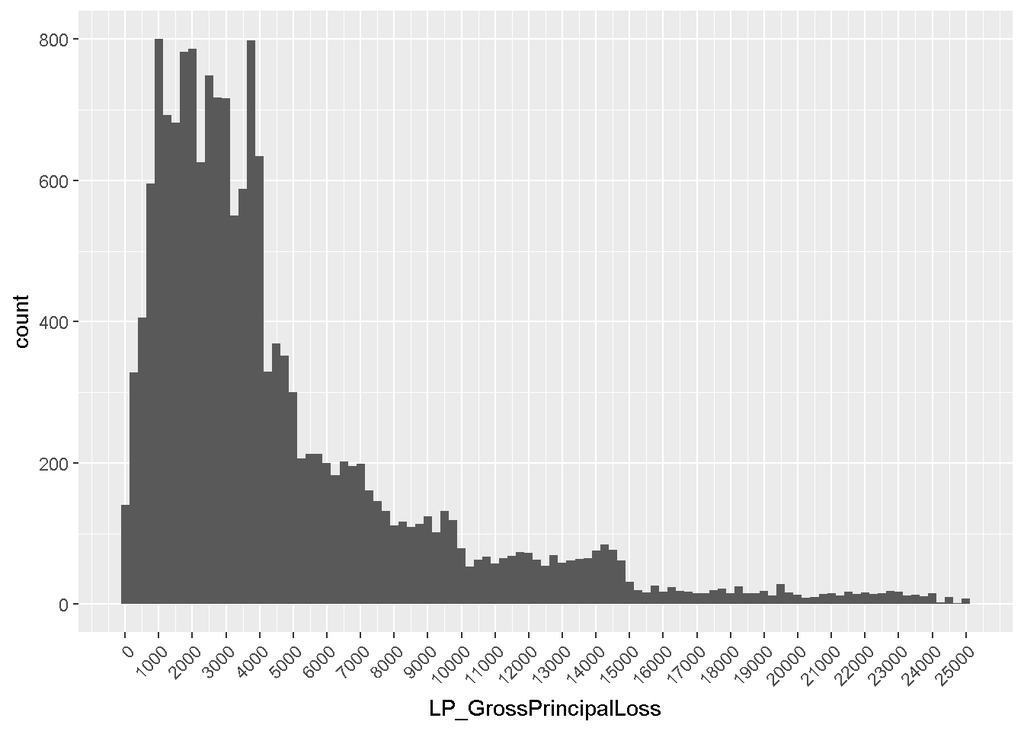

通过summary可以看到，75%的借款是没有损耗的，但最大的耗损也达到了25000。大部分耗损都在15000以内，5000以上的贷款耗损密度并不大，但是分布较广。

查看先前贷款的拖欠账户数目和拖欠总额。

```
##    Min. 1st Qu.  Median    Mean 3rd Qu.    Max.    NA's
##  0.0000  0.0000  0.0000  0.5921  0.0000 83.0000     697
```

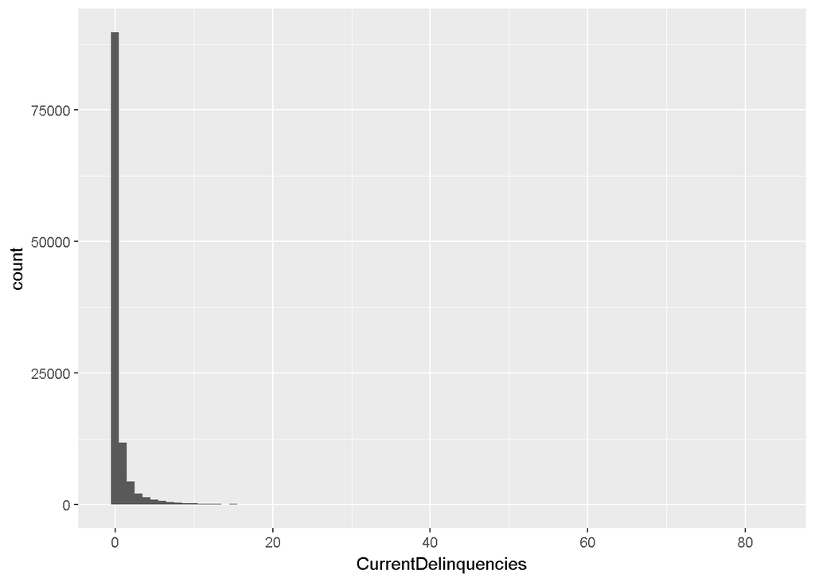

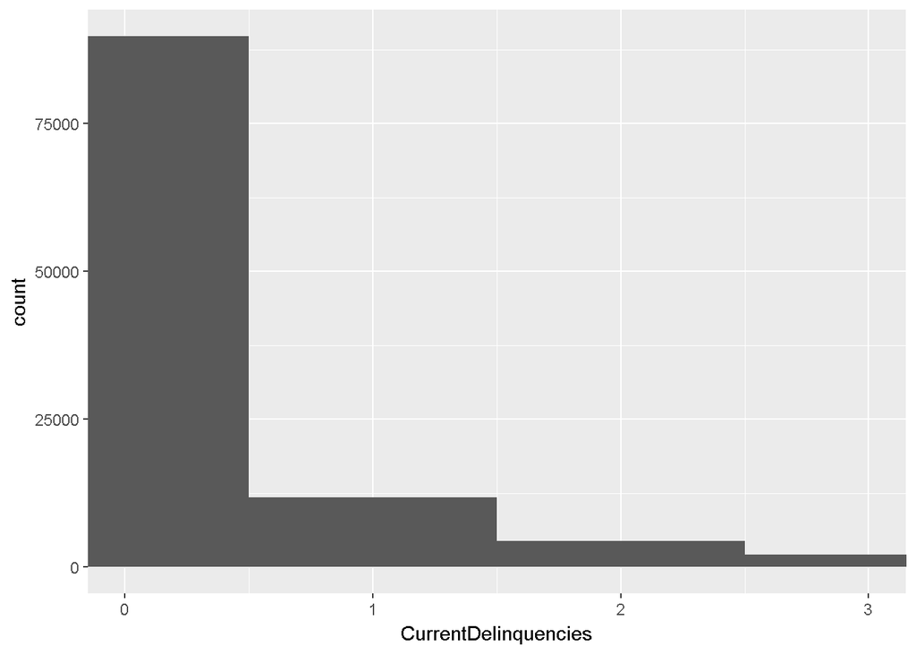

通过summary可以看出，大部分之前有借款记录的人并没有拖欠，最大的拖欠账户数目可达83个。如果忽略top5的话，会发现95%的拖欠账目少于4。

```
##     Min.  1st Qu.   Median     Mean  3rd Qu.     Max.     NA's
##      0.0      0.0      0.0    984.5      0.0 463881.0     7622
```

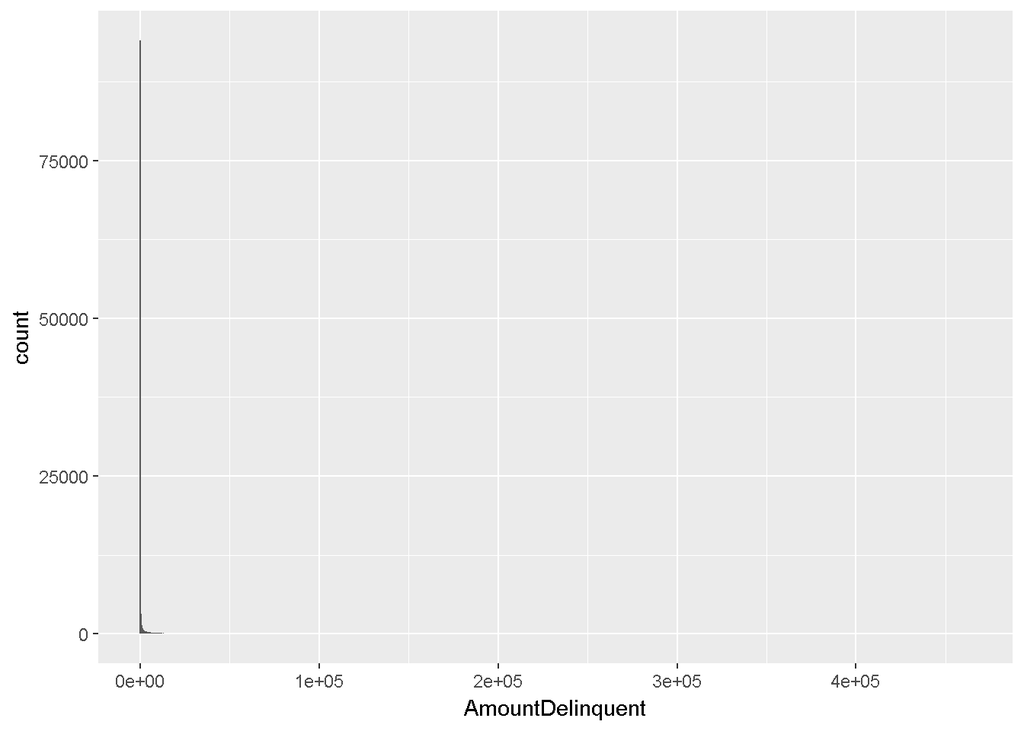

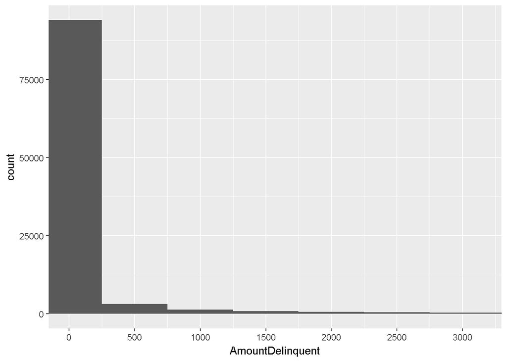

通过summary可以看出，大部分之前有借款记录的人并没有拖欠，最大的拖欠总金额可达463881，已经远远超过之前看到的贷款耗损总额了，猜测可能此条目不止一个拖欠账户（通过代码查看得知是3个，平均额依旧很高）。如果忽略top5的话，会发现95%的拖欠总额小于4000，大部分也都在1500元以内。

最后查看先前贷款的未偿还金额。

```
##    Min. 1st Qu.  Median    Mean 3rd Qu.    Max.    NA's
##       0       0    1627    2930    4127   23451   91852
```

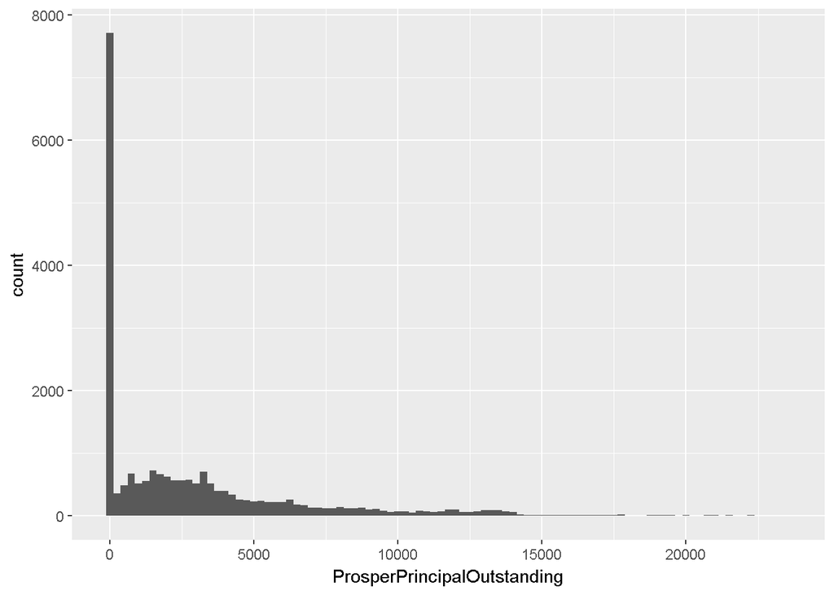

75%的先前贷款的拖欠金额不超过4127，最高额为23451，和之前看到的贷款耗损的最高值差不多。大部分的拖欠不会超过15000。这个特征的分布和贷款总耗损有一定的相似之处。

# 单变量分析

### 你的数据集结构是什么？

这个数据集包含113937条记录，每条记录有81个特征，或者说本数据集一共包含81条特征。

其中观察到的有序因子变量为： 1.ProsperRating..Alpha.，排除空值顺序由低到高为：‘HR’,‘E’,‘D’,‘C’,‘B’,‘A’,‘AA’。 2.ProsperRating..numeric.，排除0代表的空值，信用评级随着数字的升高而升高。 3.LoanStatus，顺序为：‘Cancelled’,‘Chargedoff’,‘Completed’,‘Current’,‘Defaulted’,‘Final PaymentInProgress’,‘Past Due (1-15 days)’,‘Past Due (16-30 days)’,‘Past Due (31-60 days)’,‘Past Due (61-90 days)’,‘Past Due (91-120 days)’,‘Past Due (>120 days)’。 4.ProsperScore，随着数字的升高，风险越小。

观察到的特性有： 信用评级、风险系数、预估回报都可以看成正态分布，剩下的几乎所有的特征都是长尾分布，拖欠天数更是可以看成由两个正态分布组成的长尾分布。 先前贷款未偿还额和总拖欠的几个数据点和贷款总耗损的几个数据点很相近，例如大部分的贷款耗损和先前未偿还额都不会超过15000，且最大额是在25000或接近25000。

### 你的数据集内感兴趣的主要特性有哪些？

我所感兴趣的主要特征就是EstimatedReturn预估回报和LP_GrossPrincipalLoss贷款总耗损。这二者猜测也许都和ProsperRating信用评级和ProsperScore风险系数有些关系。

### 你认为数据集内哪些其他特征可以帮助你探索兴趣特点？

按月还贷额、借贷比、拖欠时间和一些耗损记录应该也可以结合信用评级和风险系数用来预估耗损和回报。

### 在已经探究的特性中，是否存在任何异常分布？你是否对数据进行一些操作，如清洁、调整或改变数据的形式？如果是，你为什么会这样做？

信用评级，发现A和AA顺序错误，并且为了和数字信用评级的顺序一样，因此需要重新排列字母信用评级——更改A和AA的错误顺序，把NA排为第一个。且数字评级包含空值，但是特征说明中规定空值NA应为0，因此也进行了修改。 风险系数应按照特征说明将1-11更改0-10，并改为因子变量，但为了后面计算相关系数方便，因此保留num特征，并新建一个因子变量。 贷款用途和风险系数处理的方法相同，保留原变量，转换因子变量并新建。 贷款状态分布中有序因子的排序有错误，也进行了修改。

# 双变量绘图选择

筛选出可以计算相关性的特征，进行相关矩阵和GGPAIRS绘制。

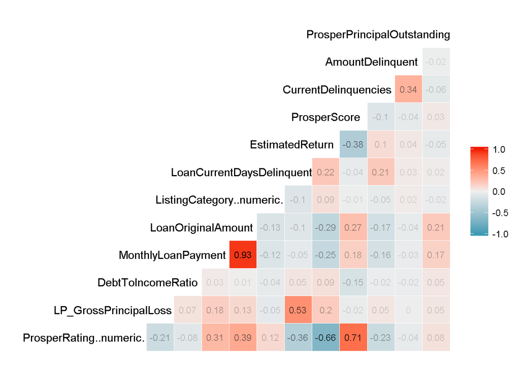

从ggcor图中可以找到关系系数最高的几对特征就是贷款初始金额和按月还贷额(0.932)、风险分数和信用评级(0.705)、信用评级和预估回报(-0.66)、拖欠天数和贷款总耗损(0.534)。因此我们可以知道，对耗损和预估回报起到直接影响的特征应该是拖欠天数、评级和风险系数。观察相关系数矩阵我们可以推测出，月付款和贷款初始金额可能会通过和信用评级的关系间接影响预估回报。

首先查看拖欠天数和总耗损。

```
##
##  Pearson's product-moment correlation
##
## data:  ld_sub$LoanCurrentDaysDelinquent and ld_sub$LP_GrossPrincipalLoss
## t = 213.22, df = 113940, p-value < 2.2e-16
## alternative hypothesis: true correlation is not equal to 0
## 95 percent confidence interval:
##  0.5298950 0.5381959
## sample estimates:
##       cor
## 0.5340583
```

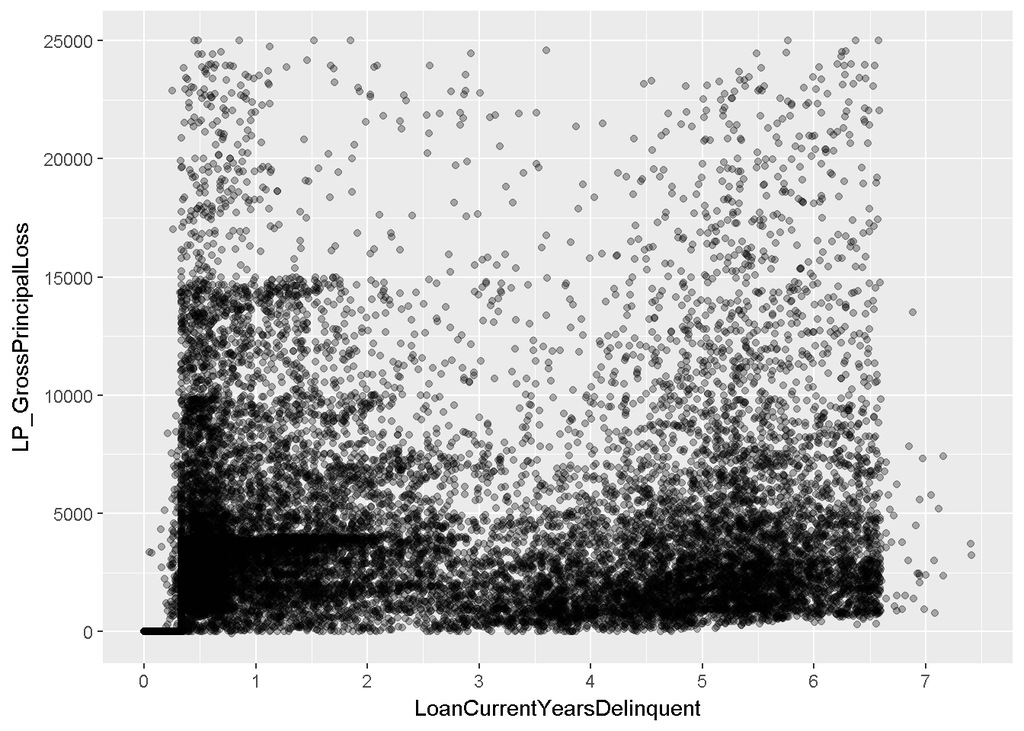

贷款耗损先是随着拖欠天数的增加，而密度下降，但在2-3年这个区间则有个转折，而后耗损密度加大。高额耗(大于15000)在拖欠一年内和拖欠4-6年的区间内密度稍高。

然后查看信用评级、风险系数分别和预估回报的关系。

```
##
##  Pearson's product-moment correlation
##
## data:  ld_sub$ProsperRating..numeric. and ld_sub$EstimatedReturn
## t = -255.89, df = 84851, p-value < 2.2e-16
## alternative hypothesis: true correlation is not equal to 0
## 95 percent confidence interval:
##  -0.6637612 -0.6561656
## sample estimates:
##        cor
## -0.6599802
```

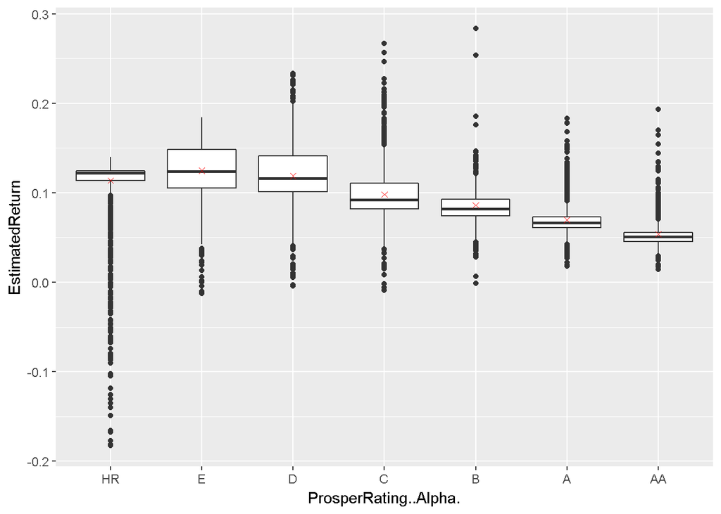

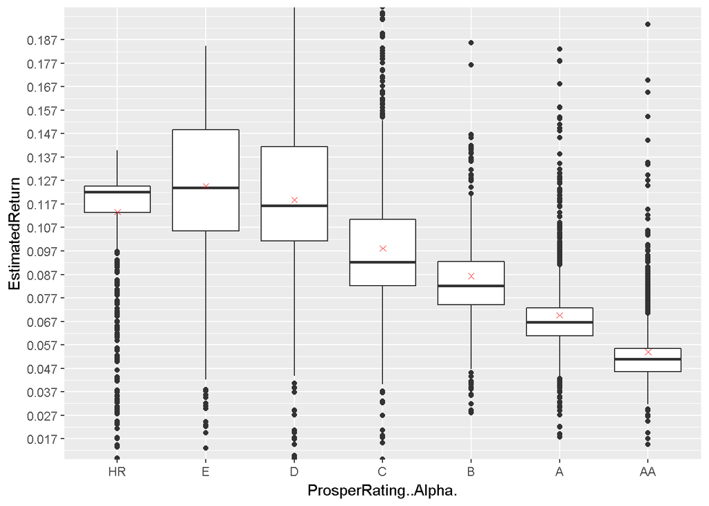

第一幅图中可以看出各个评级预估回报的IQR在0.05-0.2区间内，但这里选择0.017-0.192这一区间来放大箱图，因为从上面的直方图分布中，可以看出大部分的预估回报都这一区间。各信用评级预估回报的1.5倍IQR值随着信用评级的由高到低是二次凸函数的变化趋势；但平均值和中位值则是随着信用评级的升高而降低（只是HR的平均值比E的略低，猜测可能是异常低值将平均值拉下）。总体来说，预估回报较高的点基本分布在E和D评级中，C评级也有少量回报很高的点（异常值），HR评级拥有着回报率最低甚至是负回报的点（异常值）。A和AA的IRQ在总预估回报平均值0.096以下。

```
##
##  Pearson's product-moment correlation
##
## data:  ld_sub$ProsperScore and ld_sub$EstimatedReturn
## t = -120.85, df = 84851, p-value < 2.2e-16
## alternative hypothesis: true correlation is not equal to 0
## 95 percent confidence interval:
##  -0.3889362 -0.3774554
## sample estimates:
##        cor
## -0.3832106
```

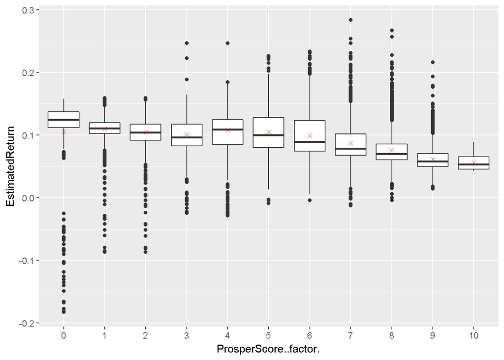

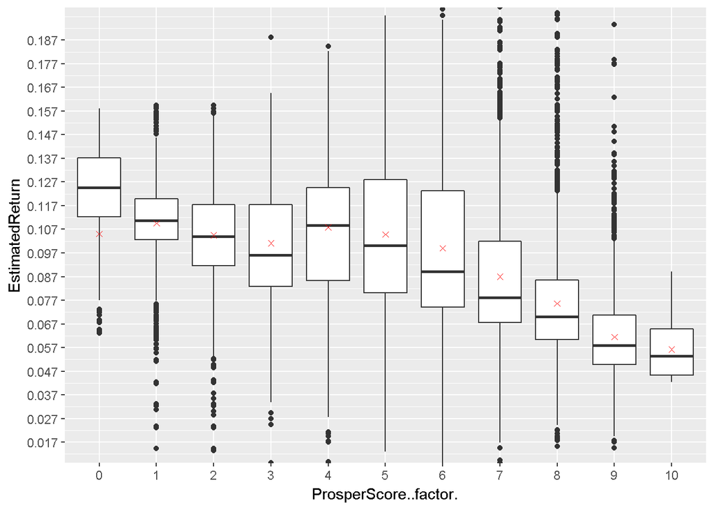

依旧放大到0.017-0.192这个区间，发现虽然均值和中位值的变化小有波动，但都是呈现预估回报随着风险系数的升高（风险系数越高，风险越小）而下降的趋势。忽略异常值的话，4、5、6系数有着回报最高的点，同时也包含一些负回报的异常点。包含负回报最多的就是0风险系数。因此从相反的方向来看，预估回报的各个均值和中位值虽然随着风险系数(安全性)的升高而呈现总体降低的趋势，但是各风险系数预估回报的最低值却是升高的趋势，可以说是安全性越来越高。信用评级同理。

信用评级和风险系数有着跟高的相关度，下面进行查看。

```
##
##  Pearson's product-moment correlation
##
## data:  ld_sub$ProsperScore and ld_sub$ProsperRating..numeric.
## t = 289.74, df = 84851, p-value < 2.2e-16
## alternative hypothesis: true correlation is not equal to 0
## 95 percent confidence interval:
##  0.7018231 0.7085876
## sample estimates:
##       cor
## 0.7052214
```

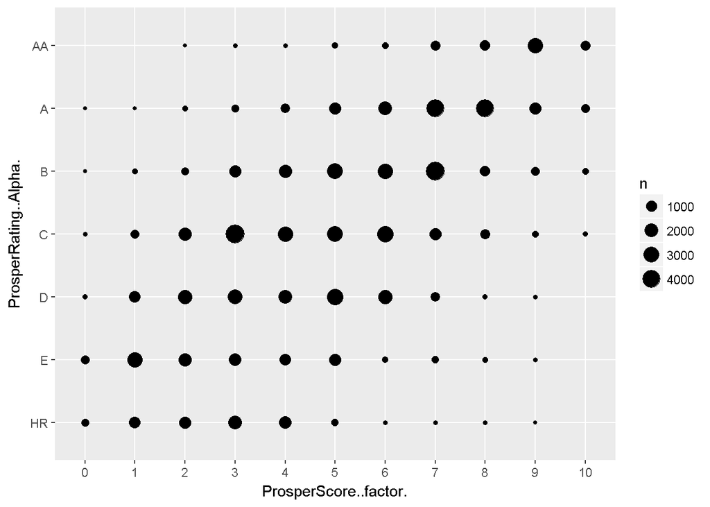

在传送数据集的时候，只是删去了信用评级为空的条目，但是图中也并没有看到风险系数为空的条目，看来这两个特征的缺失是“同时性的”。可以看到风险与信用评估是具有方向一致性的，基本都是双底或者双高，很少有一高一低的记录。

接下来查看按月还贷额、贷款初始金额分别和信用评级的关系。

```
##
##  Pearson's product-moment correlation
##
## data:  ld_sub$ProsperRating..numeric. and ld_sub$MonthlyLoanPayment
## t = 109.07, df = 113940, p-value < 2.2e-16
## alternative hypothesis: true correlation is not equal to 0
## 95 percent confidence interval:
##  0.3022041 0.3127193
## sample estimates:
##       cor
## 0.3074711
```

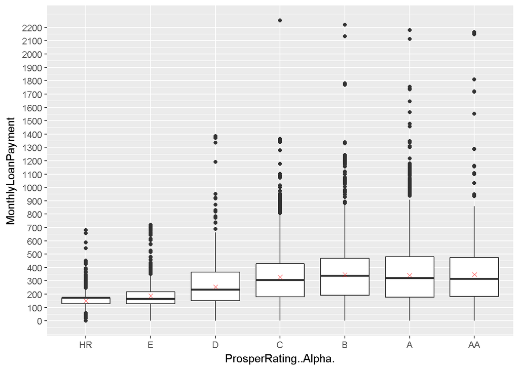

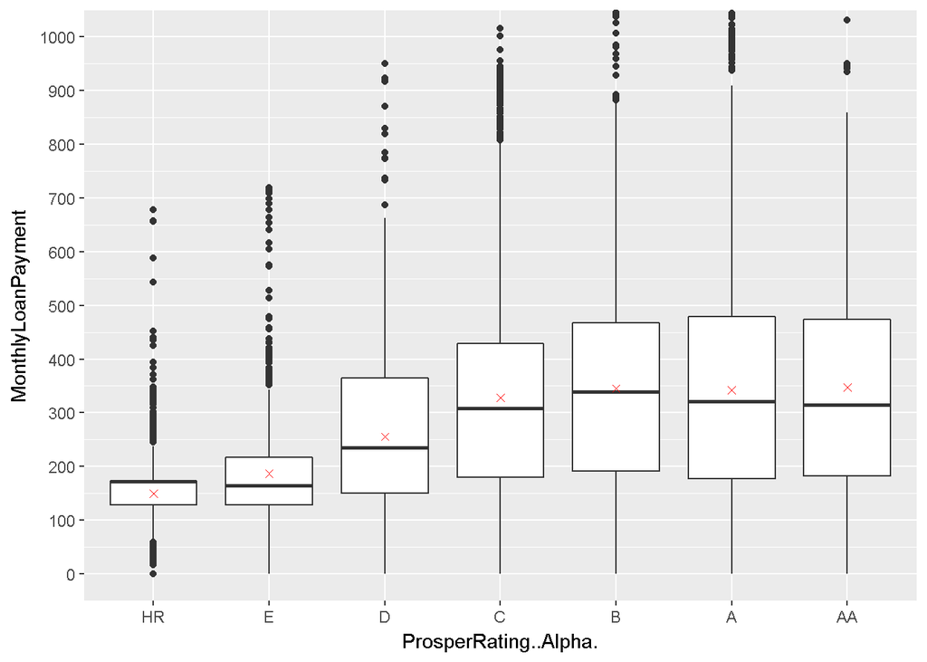

```
##
##  Pearson's product-moment correlation
##
## data:  ld_sub$ProsperRating..numeric. and ld_sub$LoanOriginalAmount
## t = 144.39, df = 113940, p-value < 2.2e-16
## alternative hypothesis: true correlation is not equal to 0
## 95 percent confidence interval:
##  0.3883675 0.3981844
## sample estimates:
##       cor
## 0.3932871
```

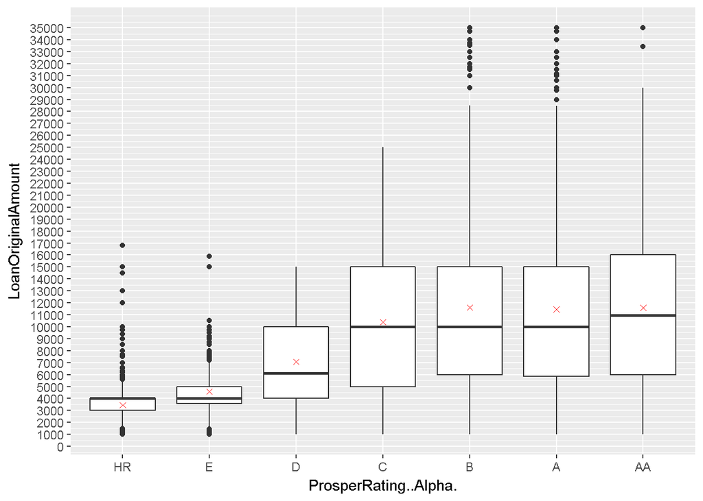

贷款初始金额和信用评级的分布特征和按月还贷金额非常接近。25000以上的贷款条目非常少。

在相关系数矩阵中，关系最密切的就是贷款初始金额和按月还贷额，下面查看这二者的关系。

```
##
##  Pearson's product-moment correlation
##
## data:  ld_sub$LoanOriginalAmount and ld_sub$MonthlyLoanPayment
## t = 867.82, df = 113940, p-value < 2.2e-16
## alternative hypothesis: true correlation is not equal to 0
## 95 percent confidence interval:
##  0.9312165 0.9327426
## sample estimates:
##       cor
## 0.9319837
```

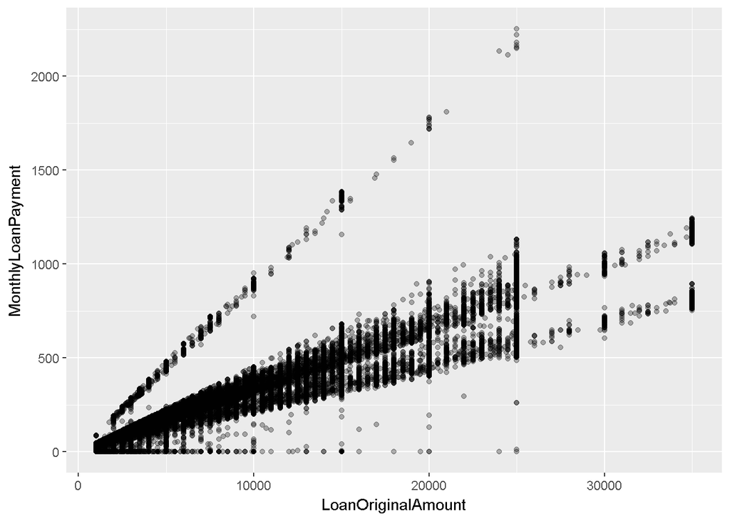

可以明显得看到几组线性关系，一小部分的斜率很大。根据上面的相关系数猜测，这几簇线性关系的划分也许和信用评级或者风险系数(由于风险系数和信用评级的高相关性)有关。

# 双变量分析

### 探讨你在这部分探究中观察到的一些关系。这些感兴趣的特性与数据集内其他特性有什么区别？

风险系数和信用评级是相辅相成的关系，预估回报都随着二者的升高而下降。贷款耗损和拖欠天数并不能用简单的一次线性函数关系来表示，无论是耗损密度还是耗损值都有类似二次凹函数的关系，不只是拖欠密度大于15000的高额耗损密度在拖欠一年内和4-6年内也较高。按月还贷额和贷款初始金额有着很密切的关系，贷款初始金额越高，按月还贷额越高。

### 你是否观察到主要特性与其他特性之间的有趣关系？

信用评级和很多其他特性都有着或多或少的关系。评级越高，月付款和初始金额都越高。

### 你发现最强的关系是什么？

贷款初始金额越高，按月还贷额越高。

# 多变量绘图选择

首先查看不同信用评级下的预估回报和总耗损的密度分布。

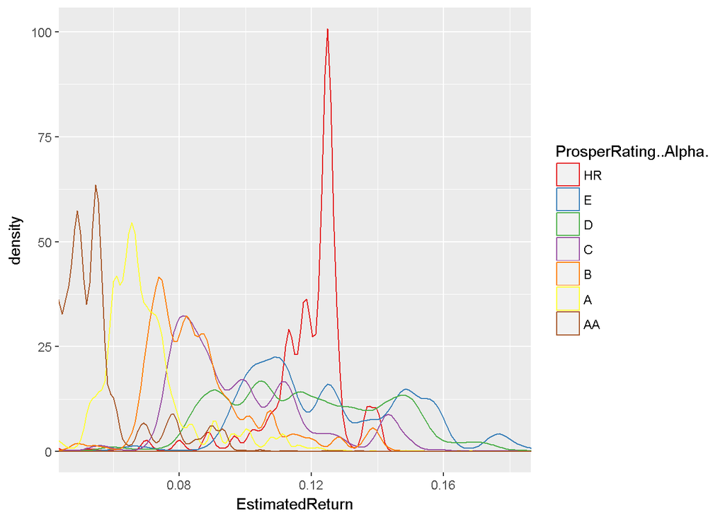

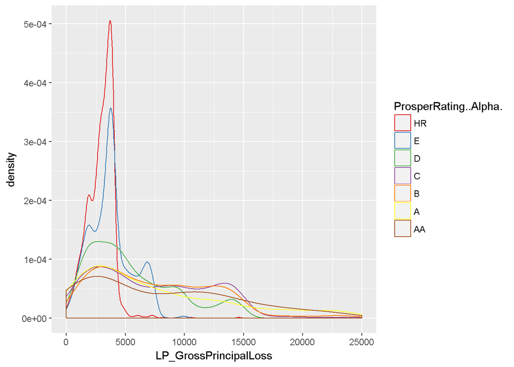

B、A、AA这三个评级的回报分布随着信用评级的升高而往低回报方向平移，且低回报的密度还在升高。D和E在稍高回报的区间分布较广且平缓，HR的高回报区间虽然窄，但是密度分布却有个不小的高峰。可以看出来，预估回报是随着信用评级的升高而降低的。 HR和E这样低评级的总耗损在小额区间内有着很高的密度，高信用评级的耗损虽然密度一直都很低缓，但是额度分布广，且像A和AA这种评级内的最大耗损就是整体耗损的最大值了。